# Business Problem

### Creating a DataFrame Using Pandas

```python
import pandas as pd
```

```python
df = pd.DataFrame({
    "Brand": Brand_Names,
    "Bluetooth_Version": Bud_Versions,
    "Color": Bud_Colors,
    "MRP": MRPs,
    "Selling_Price": Selling_Prices,
    "Rating": Ratings,
    "Discount_Percentage": Discount_Percentages
})
```

```python
df
```

[output not shown]

432 rows × 7 columns

```python
df["Discount Amount"] = df["MRP"] - df["Selling_Price"]
```

```python
df
```

|  | Brand | Bluetooth_Version | Color | MRP | Selling_Price | Rating | Discount_Percentage | Discount Amount |
| --- | --- | --- | --- | --- | --- | --- | --- | --- |
| 0 | Noise | 5.0 | Red | 2125 | 1593 | 3.8 | 25 | 532 |
| 1 | Noise | 5.0 | Grey | 2727 | 2399 | 3.5 | 12 | 328 |
| 2 | Mivi | 5.1 | Grey | 3464 | 3082 | 4.2 | 11 | 382 |
| 3 | JBL | 5.1 | Green | 3412 | 2490 | 4.6 | 27 | 922 |
| 4 | boAt | 5.1 | Red | 2730 | 1883 | 3.9 | 31 | 847 |
| ... | ... | ... | ... | ... | ... | ... | ... | ... |
| 427 | truke | 5.3 | Blue | 11478 | 615 | 1.8 | 74 | 10863 |
| 428 | OnePlus | 5.0 | Grey | 9690 | 713 | 2.1 | 74 | 8977 |
| 429 | JBL | 5.1 | White | 8832 | 669 | 2.1 | 84 | 8163 |
| 430 | Boult | 5.0 | Grey | 10967 | 597 | 1.6 | 82 | 10370 |
| 431 | boAt | 5.0 | Blue | 11295 | 800 | 2.2 | 87 | 10495 |

432 rows × 8 columns

```python
df["Rating_Category"] = pd.cut(
    df["Rating"],
    bins=[0, 3, 4, 4.5, 5],
    labels=["Poor", "Average", "Good", "Excellent"]
)
```

```python
df
```

|  | Brand | Bluetooth_Version | Color | MRP | Selling_Price | Rating | Discount_Percentage | Discount Amount | Rating_Category |
| --- | --- | --- | --- | --- | --- | --- | --- | --- | --- |
| 0 | Noise | 5.0 | Red | 2125 | 1593 | 3.8 | 25 | 532 | Average |
| 1 | Noise | 5.0 | Grey | 2727 | 2399 | 3.5 | 12 | 328 | Average |
| 2 | Mivi | 5.1 | Grey | 3464 | 3082 | 4.2 | 11 | 382 | Good |
| 3 | JBL | 5.1 | Green | 3412 | 2490 | 4.6 | 27 | 922 | Excellent |
| 4 | boAt | 5.1 | Red | 2730 | 1883 | 3.9 | 31 | 847 | Average |
| ... | ... | ... | ... | ... | ... | ... | ... | ... | ... |
| 427 | truke | 5.3 | Blue | 11478 | 615 | 1.8 | 74 | 10863 | Poor |
| 428 | OnePlus | 5.0 | Grey | 9690 | 713 | 2.1 | 74 | 8977 | Poor |
| 429 | JBL | 5.1 | White | 8832 | 669 | 2.1 | 84 | 8163 | Poor |
| 430 | Boult | 5.0 | Grey | 10967 | 597 | 1.6 | 82 | 10370 | Poor |
| 431 | boAt | 5.0 | Blue | 11295 | 800 | 2.2 | 87 | 10495 | Poor |

432 rows × 9 columns

```python
df.info()
```

```
<class 'pandas.core.frame.DataFrame'>
RangeIndex: 432 entries, 0 to 431
Data columns (total 9 columns):
 #   Column               Non-Null Count  Dtype
---  ------               --------------  -----
 0   Brand                432 non-null    object
 1   Bluetooth_Version    432 non-null    float64
 2   Color                432 non-null    object
 3   MRP                  432 non-null    int64
 4   Selling_Price        432 non-null    int64
 5   Rating               432 non-null    float64
 6   Discount_Percentage  432 non-null    int64
 7   Discount Amount      432 non-null    int64
 8   Rating_Category      432 non-null    category
dtypes: category(1), float64(2), int64(4), object(2)
memory usage: 27.8+ KB
```

```python
df["MRP"] = (
    df["MRP"]
    .astype(str)
    .str.replace(",", "", regex=False)
    .astype(int)
)
```

##### Converted mrp to int data type

```python
df["Selling Price"] = (
    df["Selling Price"]
    .astype(str)
    .str.replace(",", "", regex=False)
    .astype(int)
)
```

##### converted selling price to int

```python
df["Rating"] = pd.to_numeric(df["Rating"], errors="coerce")
```

##### Converted rating to float value

```python
df["Bluetooth_Version"] = pd.to_numeric(df["Bluetooth_version"], errors="coerce")
```

##### Converted Bluetooth version to float

```python
df.head()
```

|  | Brand | Bluetooth_Version | Color | MRP | Selling_Price | Rating | Discount_Percentage | Discount Amount | Rating_Category |
| --- | --- | --- | --- | --- | --- | --- | --- | --- | --- |
| 0 | Noise | 5.0 | Red | 2125 | 1593 | 3.8 | 25 | 532 | Average |
| 1 | Noise | 5.0 | Grey | 2727 | 2399 | 3.5 | 12 | 328 | Average |
| 2 | Mivi | 5.1 | Grey | 3464 | 3082 | 4.2 | 11 | 382 | Good |
| 3 | JBL | 5.1 | Green | 3412 | 2490 | 4.6 | 27 | 922 | Excellent |
| 4 | boAt | 5.1 | Red | 2730 | 1883 | 3.9 | 31 | 847 | Average |

```python
df.info()
```

```
<class 'pandas.core.frame.DataFrame'>
RangeIndex: 432 entries, 0 to 431
Data columns (total 9 columns):
 #   Column               Non-Null Count  Dtype
---  ------               --------------  -----
 0   Brand                432 non-null    object
 1   Bluetooth_Version    432 non-null    float64
 2   Color                432 non-null    object
 3   MRP                  432 non-null    int64
 4   Selling_Price        432 non-null    int64
 5   Rating               432 non-null    float64
 6   Discount_Percentage  432 non-null    int64
 7   Discount Amount      432 non-null    int64
 8   Rating_Category      432 non-null    category
dtypes: category(1), float64(2), int64(4), object(2)
memory usage: 27.8+ KB
```

```python
df.to_csv('earbuds_analysis.csv')
```

```python
df = pd.read_csv(r"C:\Users\HP\earbuds_analysis.csv")
```

```python
df.head()
```

|  | Brand | Bluetooth_Version | Color | MRP | Selling_Price | Rating | Discount_Percentage | Discount Amount | Rating_Category |
| --- | --- | --- | --- | --- | --- | --- | --- | --- | --- |
| 0 | Noise | 5.0 | Red | 2125 | 1593 | 3.8 | 25 | 532 | Average |
| 1 | Noise | 5.0 | Grey | 2727 | 2399 | 3.5 | 12 | 328 | Average |
| 2 | Mivi | 5.1 | Grey | 3464 | 3082 | 4.2 | 11 | 382 | Good |
| 3 | JBL | 5.1 | Green | 3412 | 2490 | 4.6 | 27 | 922 | Excellent |
| 4 | boAt | 5.1 | Red | 2730 | 1883 | 3.9 | 31 | 847 | Average |

```python
df.isnull().sum()
```

```
Brand                  0
Bluetooth_Version      0
Color                  0
MRP                    0
Selling_Price          0
Rating                 0
Discount_Percentage    0
Discount Amount        0
Rating_Category        0
dtype: int64
```

#### Filling Null Values

```python
num_cols = ["MRP", "Selling_Price", "Rating",
            "Discount_Percentage", "Discount Amount"]

for col in num_cols:
    df[col].fillna(df[col].median(), inplace=True)
```

```python
df.loc[df["Discount_Percentage"] > 90, "Discount_Percentage"] = 90
```

```python
df.info()
```

```
<class 'pandas.core.frame.DataFrame'>
RangeIndex: 432 entries, 0 to 431
Data columns (total 9 columns):
 #   Column               Non-Null Count  Dtype
---  ------               --------------  -----
 0   Brand                432 non-null    object
 1   Bluetooth_Version    432 non-null    float64
 2   Color                432 non-null    object
 3   MRP                  432 non-null    int64
 4   Selling_Price        432 non-null    int64
 5   Rating               432 non-null    float64
 6   Discount_Percentage  432 non-null    int64
 7   Discount Amount      432 non-null    int64
 8   Rating_Category      432 non-null    category
dtypes: category(1), float64(2), int64(4), object(2)
memory usage: 27.8+ KB
```

## EDA ( Exploratory Data Analysis )

```python
import seaborn as sns
import matplotlib.pyplot as plt
import warnings
warnings.filterwarnings('ignore')
```

```python
df.describe()
```

|  | Bluetooth_Version | MRP | Selling_Price | Rating | Discount_Percentage | Discount Amount |
| --- | --- | --- | --- | --- | --- | --- |
| count | 432.000000 | 432.000000 | 432.000000 | 432.000000 | 432.000000 | 432.000000 |
| mean | 5.149769 | 3237.837963 | 1939.798611 | 4.108796 | 36.773148 | 1298.039352 |
| std | 0.112140 | 1566.778431 | 871.189892 | 0.500456 | 15.968775 | 1437.967325 |
| min | 5.000000 | 1009.000000 | 425.000000 | 1.600000 | 10.000000 | 149.000000 |
| 25% | 5.000000 | 2167.500000 | 1224.500000 | 3.800000 | 24.000000 | 626.750000 |
| 50% | 5.150000 | 3183.500000 | 1854.000000 | 4.100000 | 36.000000 | 1006.500000 |
| 75% | 5.225000 | 4086.500000 | 2551.750000 | 4.500000 | 49.000000 | 1558.250000 |
| max | 5.300000 | 11537.000000 | 4402.000000 | 4.800000 | 90.000000 | 11009.000000 |

### Brand Distribution

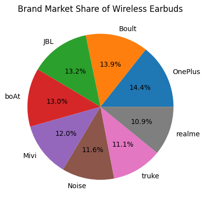

```python
df["Brand"].value_counts().plot(kind="pie", autopct="%1.1f%%")
plt.title("Brand Market Share of Wireless Earbuds")
plt.ylabel("")
plt.show()
```

#### Bluetooth Version Adoption

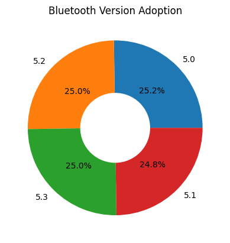

```python
bt_counts = df["Bluetooth_Version"].value_counts()
plt.pie(bt_counts, labels=bt_counts.index, autopct="%1.1f%%", wedgeprops=dict(width=0.6))
plt.title("Bluetooth Version Adoption")
plt.show()
```

#### Selling Price Distribution

Type: Histogram Purpose: Price spread

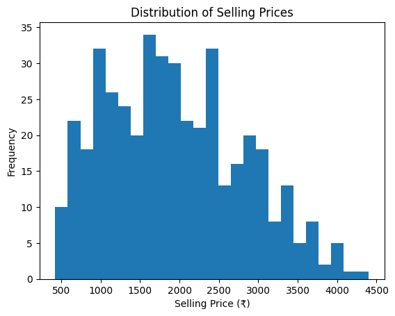

```python
plt.hist(df["Selling_Price"], bins=25)
plt.title("Distribution of Selling Prices")
plt.xlabel("Selling Price (₹)")
plt.ylabel("Frequency")
plt.show()
```

Insight: Most earbuds fall into the budget to mid-range price segment, with fewer premium products.

#### Type: Box Plot

Plot Name: Rating Boxplot

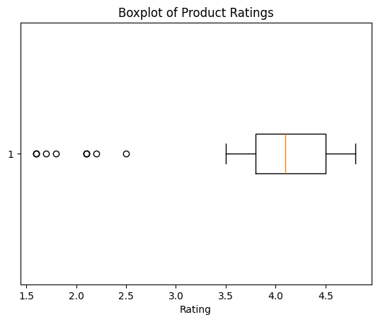

```python
plt.boxplot(df["Rating"], vert=False)
plt.title("Boxplot of Product Ratings")
plt.xlabel("Rating")
plt.show()
```

Insight: Most ratings are concentrated between 3.5 and 4.8, while a few low-rating outliers exist.

## BIVARIATE ANALYSIS

#### Rating vs Brand

Type: Violin Plot Plot Name: Brand vs Rating Distribution

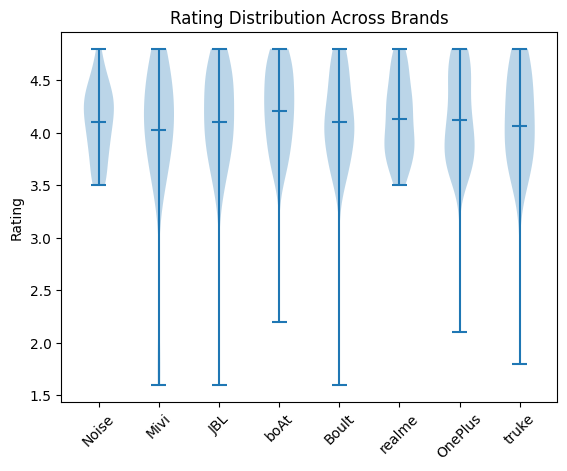

```python
plt.violinplot(
    [df[df["Brand"] == b]["Rating"] for b in df["Brand"].unique()],
    showmeans=True
)
plt.xticks(range(1, len(df["Brand"].unique()) + 1), df["Brand"].unique(), rotation=45)
plt.title("Rating Distribution Across Brands")
plt.ylabel("Rating")
plt.show()
```

Insight: Some brands show consistently higher customer satisfaction, while others have wider rating variation.

#### Discount Percentage vs Selling Price

Type: Scatter Plot Plot Name: Discount Impact on Price

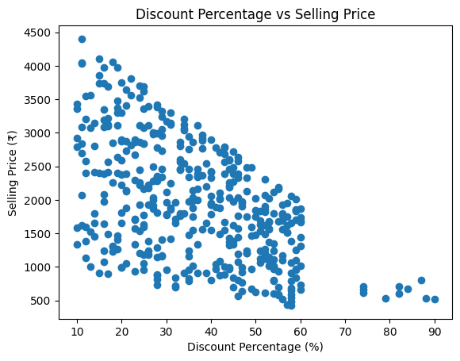

```python
plt.scatter(df["Discount_Percentage"], df["Selling_Price"])
plt.title("Discount Percentage vs Selling Price")
plt.xlabel("Discount Percentage (%)")
plt.ylabel("Selling Price (₹)")
plt.show()
```

Insight: Higher discounts are generally associated with lower selling prices, highlighting aggressive pricing strategies.

#### Average Selling Price by Bluetooth Version

Type: Line Plot Plot Name: Price Trend by Bluetooth Version

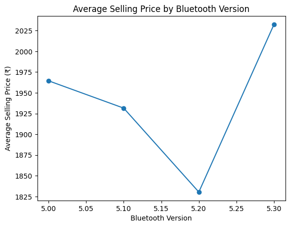

```python
avg_price_bt = df.groupby("Bluetooth_Version")["Selling_Price"].mean()
plt.plot(avg_price_bt.index, avg_price_bt.values, marker="o")
plt.title("Average Selling Price by Bluetooth Version")
plt.xlabel("Bluetooth Version")
plt.ylabel("Average Selling Price (₹)")
plt.show()
```